# Public Goods and Common Resources

November 30, 2018

## Feedback

### Good:

- The graph was easy to read and there was no chicken scratch.

### Needs improvement:

- Are the readings/sapling exercises about them mandatory or just suggested?

## Classification of goods

We can divide goods into four groups based on two definitions:

- **Rivalrous Goods** are goods whose consumption means they cannot be consumed by others. Examples: food, almost all material goods. Examples of nonrivalrous goods include: public health, quiet, works of art, national defense.
- **Excludable Goods** are goods for which the supplier can limit access to only those who pay for it. Examples: Digital movies, almost all material goods. Examples of **Nonexcludable goods** inlcude clean air, clean water, public pastures.

## Classifying types of goods

**Markets efficiently provide only the first category of goods.**

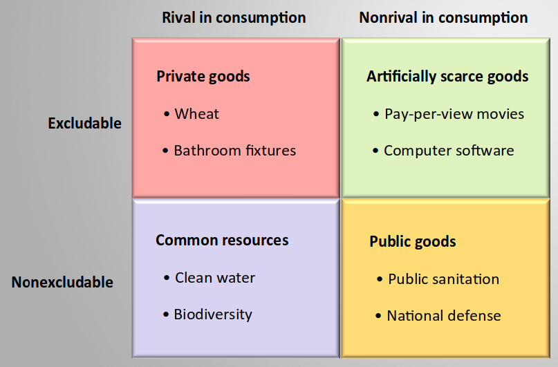

## Why Can’t Markets Provide Other Types of Goods?

- Goods that are **nonexcludable** suffer from a “free-rider” problem. Example: group projects.
- Goods that are **nonrivalrous**, the most efficient price is zero.

## Public Goods

Public goods are both **nonexcludable** and **nonrivalrous**. In this way they are the opposite of private goods.

Examples:

- National Defense
- Scientific discoveries
- Herd immunity

The **marginal social benefit** of a public good is the **sum** of the individual marginal benefits.

## Common Pool Resources

[video not shown]

## Common Pool Resources

A **common pool resource** is **rivalrous** but **nonexcludable**.

The issue is one of **overuse**. How do we get individuals to take into account the effect of their actions on the group?

- Tax or quota limits.
- Make the resource private.
- Tradable permits to use the resource.
- Community agreement to limit use.

## Community Solutions to Resource Management

“New Institutional Economics” pioneered by Nobel Laureate [Elinor Ostrom](https://en.wikipedia.org/wiki/Elinor_Ostrom).

Top-down solutions like taxes and permits are subject to issues:

- corruption
- difficulty monitoring

Communities can manage themselves if group cohesion is high:

- members share similar viewpoints and goals and are relatively equal.
- other social interactions create bonds that encourage participation.

## Artificially Scarce Goods

**Artificially scare goods** are excludable but nonrivalrous. These are things like digital media.

- Excludable so sellers charge a positive price,
- but nonrivalrous so more people could consume them and increase total social benefit.

Solution is similar to natural monopoly: regulate price (or just accept inefficiency).

## Wrapping Up

- Complete the [knowledge check](https://goo.gl/forms/dvRzD93Wp4JwAFS22) for today’s participation point.
- Please provide [feedback](https://goo.gl/forms/8SiOwdi19kN8cINJ3) on today’s lecture.